# MPX Cases in the European Union

Lian Hsiao, Brandon Ja, Rushlenne Pascual

Fall Semester, 2022

**Problem Statement**

In order to respond to the MPX outbreak in the European Union (EU), public health leadership wants to understand how case rates vary by EU region and demographic factors. Our team was tasked with visualizing monthly case rates by EU regions and comparing country case rates by demographic factors based on the EU census data. As such, we are focusing on age and population density as the demographic factors that may have an association with MPX case rates. Our hypothesis is that EU countries with a greater proportion of 15-29 year-olds (younger population) have greater MPX case rates than countries with lower proportions of 15-29 year-olds between May to August, 2022.

**Methods**

We used the following four datasets to analyze this problem: 1. Europe MPX Cases Dataset from the European Centre for Disease Prevention and Control (ECDC). It contains information on EU countries and their case counts throughout different dates from May to August of 2022. 2. Europe Population Dataset from the Eurostat. It contains information on the total population of EU countries by years from 2011 to 2022. 3. Europe Census Statistics Dataset from the EU Census. It contains information on strata of different combinations of demographic factors by EU countries in 2011. 4. World Country Regions Dataset from the PHW251 teaching team. It contains information on the different regions, sub regions, and intermediate regions that the EU countries are categorized in. There are no dates or years associated with this dataset.

We subsetted the datasets to only include relevant variables for analysis. Since we are interested in analyzing case counts in different regions by months, we created two new variables: a month variable and a monthly cases variable indicating the total number of confirmed MPX cases by months and country. We also aggregated the total MPX case count from May to August of 2022, merged in the total population data from the Europe Population Dataset and the regions data from the World Country Regions Dataset into the Europe MPX Case Dataset, as well as pivoting this into a wider format. In addition, we have also cleaned variable values for easier reading as well as inputed values for missing data. This new dataset now contains information on each EU country’s monthly cases, total cases, total population, sub region, and intermediate region as shown in the table below.

To evaluate whether MPX cases is associated with the proportion of younger population in EU countries, we subsetted relevant variables from the Europe Census Statistics Dataset and combined census strata to get the total number of people that fall under specific age ranges in each EU country. We then calculated the total population (including every age group) for each country and created a new variable showing the percentage of people in each EU country that are 15 to 29 years of age. Finally, we combined this dataset with the Europe MPX Cases Dataset to create a table showing MPX cases and percentage of population that are 15-29 years old among EU countries. This table helped informed the accuracy of our hypothesis as discussed in the following sections.

Note: although there are no statistical analysis necessary for this project, we have done visualizations and descriptive analysis on the data to answer the problem statement.

**Results**

Table 1. MPX Cases in Different EU Regions, May-August, 2022

| Country | Total Cases | Total Population | Sub Region | Intermediate Region | May | June | July | August |
| --- | --- | --- | --- | --- | --- | --- | --- | --- |
| Austria | 231 | 8978929 | Western Europe | Central Europe | 2 | 36 | 96 | 97 |
| Belgium | 671 | 11631136 | Western Europe | Western Europe | 16 | 127 | 351 | 177 |
| Bulgaria | 4 | 6838937 | Eastern Europe | Southeast Europe | 0 | 3 | 1 | 0 |
| Croatia | 25 | 3879074 | Southern Europe | Southeast Europe | 0 | 1 | 10 | 14 |
| Cyprus | 4 | 904705 | Western Asia | Middle East | 0 | 0 | 0 | 4 |
| Czechia | 41 | 10516707 | Eastern Europe | Central Europe | 1 | 7 | 15 | 18 |
| Denmark | 169 | 5873420 | Northern Europe | Nordic | 10 | 25 | 64 | 70 |
| Estonia | 10 | 1331796 | Northern Europe | Eastern Europe | 0 | 1 | 3 | 6 |
| Finland | 22 | 5548241 | Northern Europe | Nordic | 0 | 4 | 9 | 9 |
| France | 2889 | 67842582 | Western Europe | Western Europe | 17 | 481 | 1457 | 934 |
| Germany | 3329 | 83237124 | Western Europe | Central Europe | 53 | 1071 | 1619 | 586 |
| Greece | 52 | 10603810 | Southern Europe | Southeast Europe | 1 | 6 | 26 | 19 |
| Hungary | 64 | 9689010 | Eastern Europe | Central Europe | 3 | 25 | 25 | 11 |
| Iceland | 12 | 376248 | Northern Europe | Nordic | 0 | 3 | 8 | 1 |
| Ireland | 128 | 5060005 | Northern Europe | British Isles | 2 | 41 | 52 | 33 |
| Italy | 714 | 58983122 | Southern Europe | Southern Europe | 29 | 192 | 318 | 175 |
| Latvia | 4 | 1875757 | Northern Europe | Eastern Europe | 0 | 2 | 0 | 2 |
| Lithuania | 5 | 2805998 | Northern Europe | Eastern Europe | 0 | 0 | 0 | 5 |
| Luxembourg | 47 | 645397 | Western Europe | Western Europe | 0 | 5 | 25 | 17 |
| Malta | 31 | 520971 | Southern Europe | Southern Europe | 1 | 7 | 16 | 7 |
| Netherlands | 1090 | 17590672 | Western Europe | Western Europe | 43 | 320 | 586 | 141 |
| Norway | 76 | 5425270 | Northern Europe | Nordic | 2 | 15 | 39 | 20 |
| Poland | 121 | 37654247 | Eastern Europe | Central Europe | 1 | 12 | 58 | 50 |
| Portugal | 810 | 10352042 | Southern Europe | Southern Europe | 199 | 276 | 158 | 177 |
| Romania | 35 | 19038098 | Eastern Europe | Eastern Europe | 0 | 11 | 11 | 13 |
| Slovakia | 12 | 5434712 | Eastern Europe | Central Europe | 0 | 0 | 6 | 6 |
| Slovenia | 43 | 2107180 | Southern Europe | Southeast Europe | 2 | 7 | 27 | 7 |
| Spain | 6283 | 47432805 | Southern Europe | Southern Europe | 191 | 1419 | 3244 | 1429 |
| Sweden | 150 | 10452326 | Northern Europe | Nordic | 2 | 26 | 71 | 51 |

Table 2. Proportion of Younger Population and MPX Case Counts in EU Countries, May-August, 2022

| Country | Total Cases | Younger Population | Total Population | % Younger Population | Case Rate/100,000 |
| --- | --- | --- | --- | --- | --- |
| Slovenia | 43 | 538645 | 2994758 | 17.986 | 1.436 |
| Portugal | 810 | 2811695 | 15585545 | 18.040 | 5.197 |
| Greece | 52 | 2844243 | 15402922 | 18.466 | 0.338 |
| Hungary | 64 | 2677274 | 14448848 | 18.529 | 0.443 |
| Belgium | 671 | 3000164 | 15834698 | 18.947 | 4.238 |
| Bulgaria | 4 | 2038280 | 10694003 | 19.060 | 0.037 |
| Luxembourg | 47 | 139856 | 733111 | 19.077 | 6.411 |
| Romania | 35 | 5592254 | 29301750 | 19.085 | 0.119 |
| Czechia | 41 | 2993243 | 15475743 | 19.342 | 0.265 |
| Finland | 22 | 1543909 | 7969190 | 19.373 | 0.276 |
| Croatia | 25 | 1203008 | 6080104 | 19.786 | 0.411 |
| Estonia | 10 | 390894 | 1924556 | 20.311 | 0.520 |
| France | 2889 | 19216389 | 94579132 | 20.318 | 3.055 |
| Austria | 231 | 2639815 | 12673495 | 20.829 | 1.823 |
| Latvia | 4 | 658342 | 3095886 | 21.265 | 0.129 |
| Ireland | 128 | 1455500 | 6774556 | 21.485 | 1.889 |
| Slovakia | 12 | 1755602 | 8027088 | 21.871 | 0.149 |
| Poland | 121 | 12754033 | 55563231 | 22.954 | 0.218 |
| Malta | 31 | 140433 | 602515 | 23.308 | 5.145 |
| Cyprus | 4 | 296079 | 1257135 | 23.552 | 0.318 |
| Denmark | 169 | NaN | 5873420 | NaN | 2.877 |
| Germany | 3329 | NaN | 83237124 | NaN | 3.999 |
| Iceland | 12 | NaN | 376248 | NaN | 3.189 |
| Italy | 714 | NaN | 58983122 | NaN | 1.211 |
| Lithuania | 5 | NaN | 2805998 | NaN | 0.178 |
| Netherlands | 1090 | NaN | 17590672 | NaN | 6.196 |
| Norway | 76 | NaN | 5425270 | NaN | 1.401 |
| Spain | 6283 | NaN | 47432805 | NaN | 13.246 |
| Sweden | 150 | NaN | 10452326 | NaN | 1.435 |

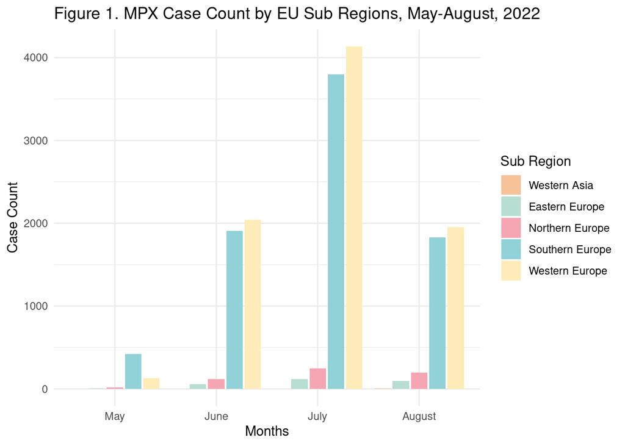

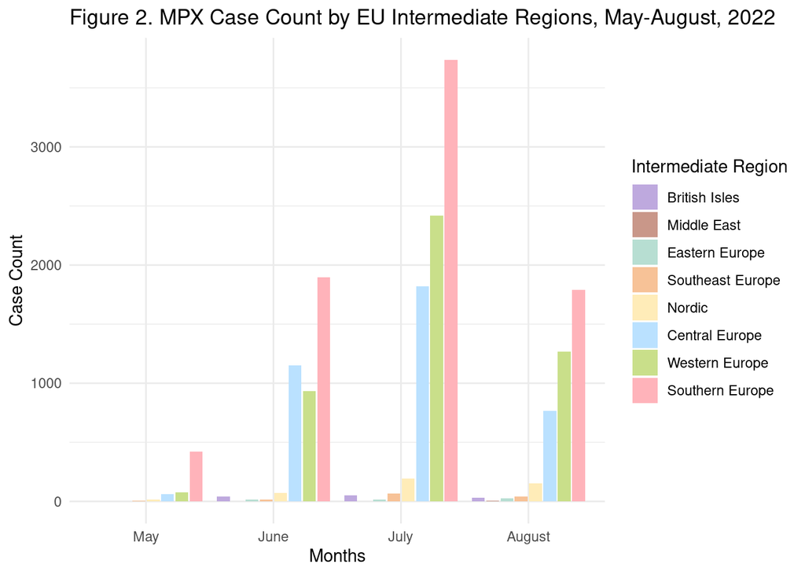

**Discussion**

*MPX Cases by Regions*

Table 1 shows the list of EU countries and their MPX case counts between May to August, 2022, as well as their total cases (throughout the four months), population, sub region, and intermediate region. France, Germany, Netherlands, and Spain had much higher total MPX cases than Bulgaria, Cyprus, Latvia, and Lithuania. When grouped by EU sub regions as shown in Figure 1, Southern and Western Europe consistently had the most MPX cases between May to August, 2022. Eastern and Northern Europe had fewer cases, while Western Asia (only including Cyprus) had little to no cases throughout the same time frame. MPX cases peaked in July, 2022. When grouped by EU intermediate regions as shown in Figure 2, Southern Europe consistently had the most MPX cases throughout May to August, 2022. Central and Western Europe had the second and third most cases throughout the same time, while the other intermediate regions have fewer cases.

*MPX Cases by Demographic Factor*

Table 2 shows a breakdown of total MPX cases by the different EU countries for individuals ages 15-29. It also includes the number of 15-29 year-olds in each country, the total population (including all age groups), and the corresponding percentage. There does not seem to be any association between the MPX case rate in EU countries and the percentage of individuals in the 15-29 age group. For example, Slovenia has approximately 18.0% 15-29 year-olds and a case rate of about 1.4% per 100,000, while Portugal also has approximately 18.0% 15-29 year olds and a case rate of about 5.2% per 100,000. Although we did not perform any statistical analyses, the information from Table 2 indicates that our hypothesis is likely not supported.